# Working with Data Assignment 1

## INTRODUCTION

This markdown file uses a variety of datasets, most of them are about information on Dublin. A detailed description of every single dataset can be found before and after each question of this assignment.

## INTRODUCTION TO TASK 1

The tast 1.2 uses the text file “dublin property trends.txt”. The Dublin property trends file shows the various property trends over 9 years, from 2007-2016 in the following two property categories - Apt Rental and House Rental. Trends include House Prices and number of Houses Built over the years.

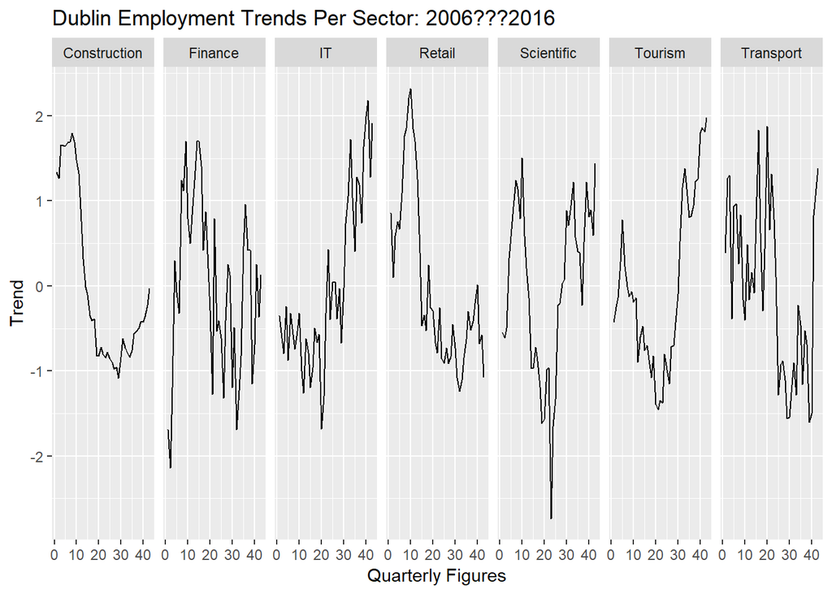

```r
#Task 1.1
warnings=FALSE
dublinEmployment <- read.delim('dublin employment trends.txt',sep=':',fill = TRUE)

qplot(data=dublinEmployment, x=Time, y=Employment, ylab='Trend', xlab='Quarterly Figures', geom='line', main='Dublin Employment Trends Per Sector: 2006???2016') + facet_grid(~Sector)
```

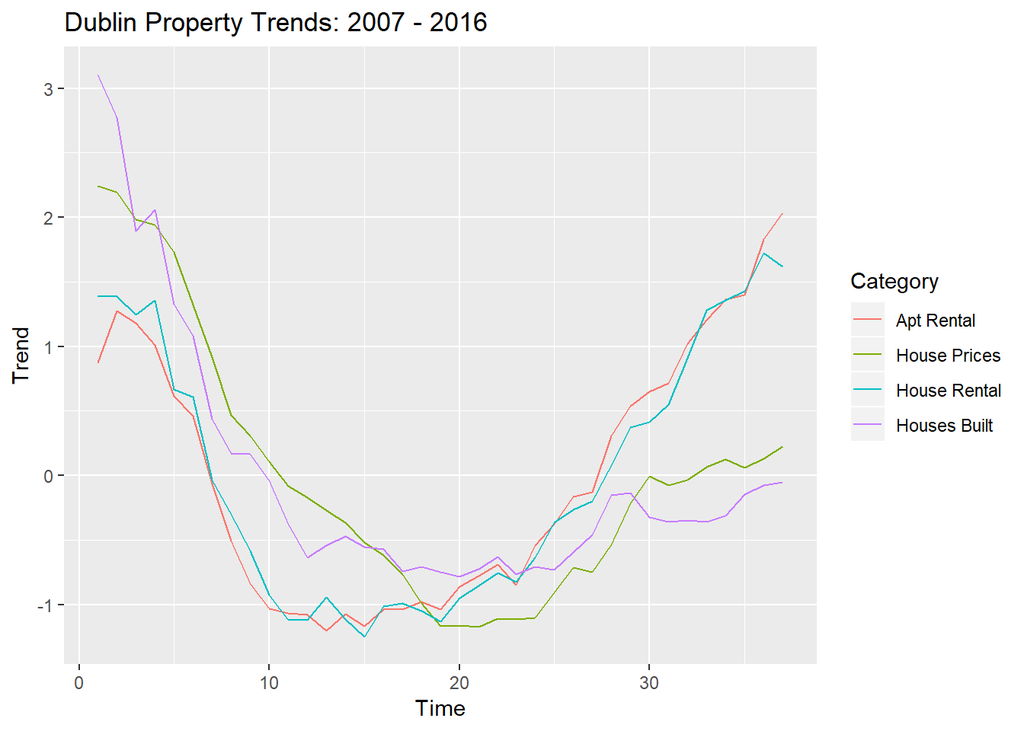

```r
#Task 1.2
dublinPropertyTrends <- read.delim('dublin property trends.txt',sep='\t')

qplot(data=dublinPropertyTrends, x=Time, y=Trend, colour=Category, ylab='Trend', xlab='Time', geom='line', main='Dublin Property Trends: 2007 - 2016')
```

### REPORT ON TASK 1.1

The required ask was to recreate an employment trends plot, from an already created plot. A general trend can be observed in the sectors Construction, Finance, Scientific and Retail. All four sectors have high employment rate in the years 2008-2010. Apart from Scientific, the other three sectors have had a lesser employment rate after the boom. Although Scientific sector had the worst employment rate in the year 2011, it has relatively come back to a normal state afterwards.

The sectors IT and Tourism seem to have a very low employment rate in the beginning and have massively boomed in the recent years.

The Transport sector, after hitting an all low employment rate in the years 2012-2015, have sharply risen from the year 2016.

### REPORT ON TASK 1.2

The required ask was to recreate a Dublin property trends plot. From the graph, it can be clearly seen that the number of houses built was at its highest in the year 2007 and then very few houses were built since then, resulting in a sharp downward trend in the curve. As a result of this, the house prices also reduced over the years.

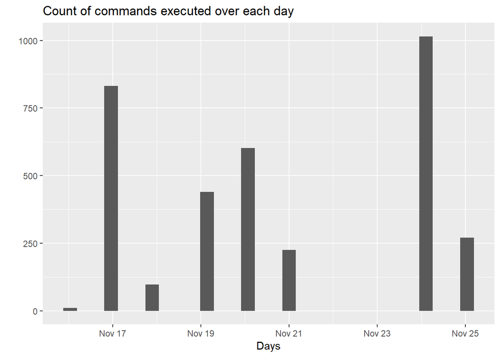

```r
#5.1 Analytic

history_database<-read_fwf(file='history_databaseAssignment',fwf_cols(Time=c(1,13), Command=c(15, 1000)))
history_database<-as.data.frame(history_database)

#Coverting milliseconds to date time
history_database$Time <- as.POSIXct(history_database$Time/1000, origin = "1970-01-01")

NumberofDays <- group_by(history_database, Days=as_date(Time))

qplot(data=NumberofDays,Days,main='Count of commands executed over each day')
```

```r
dplyr::summarise(NumberofDays, length(Days))
```

```
## # A tibble: 8 x 2
##   Days       `length(Days)`
##   <date>              <int>
## 1 2018-11-16             10
## 2 2018-11-17            832
## 3 2018-11-18             97
## 4 2018-11-19            439
## 5 2018-11-20            602
## 6 2018-11-21            225
## 7 2018-11-24           1015
## 8 2018-11-25            270
```

```r
length(unique(NumberofDays$Days))
```

```
## [1] 8
```

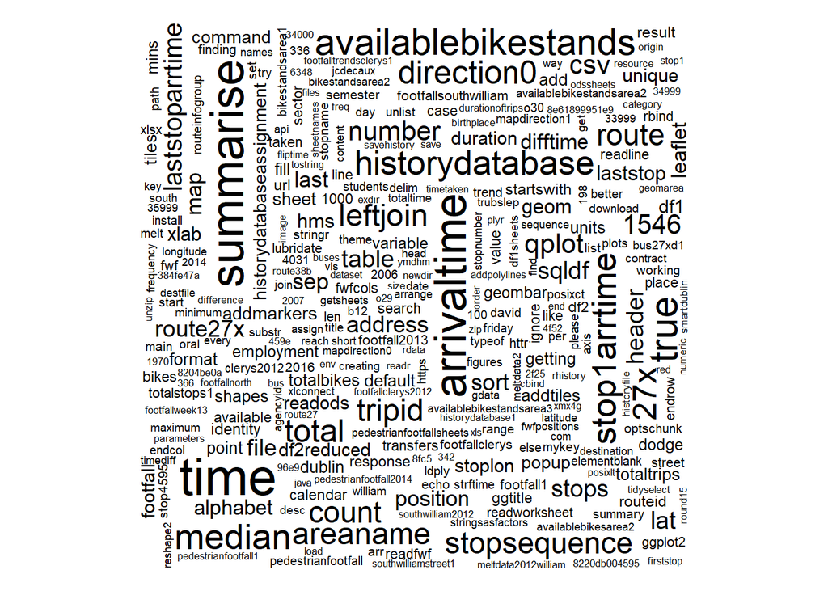

```r
#Creating a wordcloud
history_database_commands<-read_fwf(file='history_databaseAssignment',fwf_cols(Command=c(15, 1000)))
write.table(history_database_commands,"commands.txt",sep="\t",row.names=FALSE)

TextCommands<-paste(readLines("commands.txt"),collapse = " ")

TextCommands1<-gsub(pattern="\\W", replace =" ", TextCommands)

TextCommands1 <- stripWhitespace(TextCommands1)

TextCommands1<-tolower(TextCommands1)

TextCommands1<-removeWords(TextCommands1,stopwords())

wordcloud(TextCommands1)
```

### Report on Task 5.1

The history_database file was read into R using read_fwf command. The time was converted from milliseconds to a date and time format, showing on which day and what time the commands were run. In order to calculate the number of days that I had spent on working on this assignment, I grouped the file based on days and found that I have totally spent 8 days working on this assignment. Using a qplot to visualize this, it is clear that the maximum commands were run on 24th November compared to other days.

### Report for Task 5.2 (Personal Reflection)

I would like to give an account of what I have learnt in the working with data course so far and what I have learnt by performing this assignment:

1. The knowledge of how to work with various datasets, data structures and how to convert them to the desired format has been acquired.
2. The ability to perform basic data analysis, defining a dataset, cleaning a dataset, creating desired subsets, performing grouping, joining multiple datasets and summarizing has tremendously improved.
3. Although, I have learnt how to do these basic functions, I feel I run into error majorly while trying to convert any data into the format I desire and majorly while converting the date time formats. I usually have to lookup on the materials provided or by performing the help function in R or by googling about the error. This is the major area of improvement that I have to work on in the future. Maximum amount of time was spent majorly on this area.

Some of the challenges I faced:

While running the datasets for 3rd and 4th task, my RStudio would often hang and I had to restart the session every single time. I ran into java out of memory space error several times, as I started working on the 4th task. The solution was to clear the environment variables and to restart R several times for the memory to actually get empty.

Another major problem was, as I tried to knit all of the tasks in one Rmd file together, my system completely hanged leading me to submit this assignment in different Rmd files, as I have done some complex calculations in 3rd and 4th task, which takes a lot of time while trying to run even in the normal way.

Reflection on time management:

I have taken a little more time than it was necessary to perform this assignment. This was majorly because some of the datasets required handling them in a new format that I have not worked before, so it took some time to understand the dataset and to be able to perform the functions. Instead of spending 8 days, it would have been sufficient if I had spent only 5 days by just concentrating on this assignment. I also made the mistake of not writing the reports then and there as I finished a particular task. I wrote the report of every task only in the end, after finishing all 5 tasks completely which led me to re-run all the code again, leading me to spend more time on this again.

Area of improvement:

I hope to get into the shoes of a real data analyst and be able to define, clean and play around with a dataset with ease. This will happen as I familiarise myself more with R. This assignment was an overall eye-opener, showing me as to how a data scientist/analyst should really perform each task with any dataset.